# Vanilla CNN and Fine-Tune VGG16 - for Dogs and Cats Classificationn

Here we define a new dense neural networks, of only two (neuronal/trainable) layers.

```python
inputs = keras.Input(shape=(5, 5, 512))
x = layers.Flatten()(inputs)
x = layers.Dense(256)(x)
x = layers.Dropout(0.5)(x)
outputs = layers.Dense(1, activation="sigmoid")(x)
model = keras.Model(inputs, outputs)
```

```python
model.summary()
```

```
Model: "functional_4"
```

```
┏━━━━━━━━━━━━━━━━━━━━━━━━━━━━━━━━━┳━━━━━━━━━━━━━━━━━━━━━━━━┳━━━━━━━━━━━━━━━┓
┃ Layer (type)                    ┃ Output Shape           ┃       Param # ┃
┡━━━━━━━━━━━━━━━━━━━━━━━━━━━━━━━━━╇━━━━━━━━━━━━━━━━━━━━━━━━╇━━━━━━━━━━━━━━━┩
│ input_layer_2 (InputLayer)      │ (None, 5, 5, 512)      │             0 │
├─────────────────────────────────┼────────────────────────┼───────────────┤
│ flatten_1 (Flatten)             │ (None, 12800)          │             0 │
├─────────────────────────────────┼────────────────────────┼───────────────┤
│ dense_1 (Dense)                 │ (None, 256)            │     3,277,056 │
├─────────────────────────────────┼────────────────────────┼───────────────┤
│ dropout_1 (Dropout)             │ (None, 256)            │             0 │
├─────────────────────────────────┼────────────────────────┼───────────────┤
│ dense_2 (Dense)                 │ (None, 1)              │           257 │
└─────────────────────────────────┴────────────────────────┴───────────────┘
```

```
 Total params: 3,277,313 (12.50 MB)
```

```
 Trainable params: 3,277,313 (12.50 MB)
```

```
 Non-trainable params: 0 (0.00 B)
```

```python
model.compile(loss="binary_crossentropy",
              optimizer="rmsprop",
              metrics=["accuracy"])

callbacks = [
    keras.callbacks.ModelCheckpoint(
      filepath="./models/feature_extraction.keras",
      save_best_only=True,
      monitor="val_loss")
]
history = model.fit(
    train_features, train_labels,
    epochs=20,
    validation_data=(val_features, val_labels),
    callbacks=callbacks)
```

```
63/63 ━━━━━━━━━━━━━━━━━━━━ 3s 41ms/step - accuracy: 0.8433 - loss: 43.8451 - val_accuracy: 0.8930 - val_loss: 22.3681
63/63 ━━━━━━━━━━━━━━━━━━━━ 3s 42ms/step - accuracy: 0.9685 - loss: 3.6171 - val_accuracy: 0.9710 - val_loss: 5.6173
63/63 ━━━━━━━━━━━━━━━━━━━━ 2s 32ms/step - accuracy: 0.9843 - loss: 1.9864 - val_accuracy: 0.9740 - val_loss: 4.7993
63/63 ━━━━━━━━━━━━━━━━━━━━ 2s 26ms/step - accuracy: 0.9921 - loss: 1.1131 - val_accuracy: 0.9720 - val_loss: 6.0044
63/63 ━━━━━━━━━━━━━━━━━━━━ 2s 29ms/step - accuracy: 0.9973 - loss: 0.4798 - val_accuracy: 0.9790 - val_loss: 3.7801
63/63 ━━━━━━━━━━━━━━━━━━━━ 2s 28ms/step - accuracy: 0.9877 - loss: 1.2857 - val_accuracy: 0.9730 - val_loss: 5.1995
63/63 ━━━━━━━━━━━━━━━━━━━━ 2s 27ms/step - accuracy: 0.9882 - loss: 1.2168 - val_accuracy: 0.9760 - val_loss: 4.1445
63/63 ━━━━━━━━━━━━━━━━━━━━ 2s 28ms/step - accuracy: 0.9960 - loss: 0.5138 - val_accuracy: 0.9730 - val_loss: 4.1599
63/63 ━━━━━━━━━━━━━━━━━━━━ 2s 26ms/step - accuracy: 0.9975 - loss: 0.3402 - val_accuracy: 0.9710 - val_loss: 4.6460
63/63 ━━━━━━━━━━━━━━━━━━━━ 2s 28ms/step - accuracy: 0.9983 - loss: 0.1833 - val_accuracy: 0.9670 - val_loss: 9.6526
63/63 ━━━━━━━━━━━━━━━━━━━━ 2s 28ms/step - accuracy: 0.9980 - loss: 0.0643 - val_accuracy: 0.9690 - val_loss: 7.5163
63/63 ━━━━━━━━━━━━━━━━━━━━ 2s 28ms/step - accuracy: 0.9935 - loss: 1.0697 - val_accuracy: 0.9750 - val_loss: 5.3213
63/63 ━━━━━━━━━━━━━━━━━━━━ 2s 31ms/step - accuracy: 0.9985 - loss: 0.0977 - val_accuracy: 0.9770 - val_loss: 3.8697
63/63 ━━━━━━━━━━━━━━━━━━━━ 2s 34ms/step - accuracy: 0.9992 - loss: 0.0164 - val_accuracy: 0.9750 - val_loss: 6.6999
63/63 ━━━━━━━━━━━━━━━━━━━━ 2s 30ms/step - accuracy: 0.9962 - loss: 0.1256 - val_accuracy: 0.9730 - val_loss: 6.2032
63/63 ━━━━━━━━━━━━━━━━━━━━ 3s 47ms/step - accuracy: 0.9977 - loss: 0.2196 - val_accuracy: 0.9770 - val_loss: 5.4822
63/63 ━━━━━━━━━━━━━━━━━━━━ 2s 30ms/step - accuracy: 1.0000 - loss: 0.0046 - val_accuracy: 0.9730 - val_loss: 6.8601
63/63 ━━━━━━━━━━━━━━━━━━━━ 2s 29ms/step - accuracy: 0.9989 - loss: 0.1517 - val_accuracy: 0.9790 - val_loss: 4.3120
63/63 ━━━━━━━━━━━━━━━━━━━━ 2s 32ms/step - accuracy: 0.9990 - loss: 0.0849 - val_accuracy: 0.9830 - val_loss: 4.8296
63/63 ━━━━━━━━━━━━━━━━━━━━ 2s 38ms/step - accuracy: 0.9975 - loss: 0.0542 - val_accuracy: 0.9790 - val_loss: 5.4762
```

**Plotting the results**

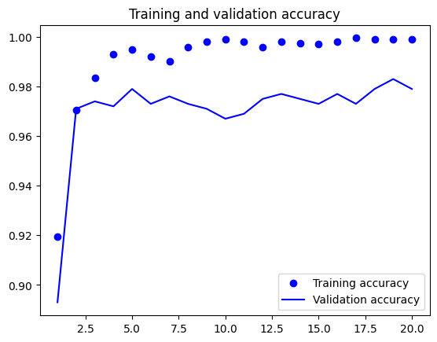

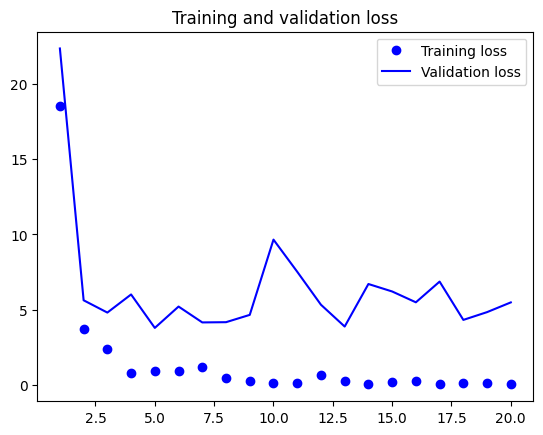

```python
import matplotlib.pyplot as plt
acc = history.history["accuracy"]
val_acc = history.history["val_accuracy"]
loss = history.history["loss"]
val_loss = history.history["val_loss"]
epochs = range(1, len(acc) + 1)
plt.plot(epochs, acc, "bo", label="Training accuracy")
plt.plot(epochs, val_acc, "b", label="Validation accuracy")
plt.title("Training and validation accuracy")
plt.legend()
plt.figure()
plt.plot(epochs, loss, "bo", label="Training loss")
plt.plot(epochs, val_loss, "b", label="Validation loss")
plt.title("Training and validation loss")
plt.legend()
plt.show()
```

```python
test_model = keras.models.load_model(
    "./models/feature_extraction.keras")
test_loss, test_acc = test_model.evaluate(x=test_features, y=test_labels)
print(f"Test accuracy: {test_acc:.3f}")
```

```
63/63 ━━━━━━━━━━━━━━━━━━━━ 0s 3ms/step - accuracy: 0.9725 - loss: 4.6435
Test accuracy: 0.971
```

### 3.2.3 Feature extraction together with data augmentation

**Instantiating and freezing the VGG16 convolutional base**

```python
conv_base  = keras.applications.vgg16.VGG16(
    weights="imagenet",
    include_top=False)
```

```python
conv_base.summary()
```

```
Model: "vgg16"
```

```
┏━━━━━━━━━━━━━━━━━━━━━━━━━━━━━━━━━┳━━━━━━━━━━━━━━━━━━━━━━━━┳━━━━━━━━━━━━━━━┓
┃ Layer (type)                    ┃ Output Shape           ┃       Param # ┃
┡━━━━━━━━━━━━━━━━━━━━━━━━━━━━━━━━━╇━━━━━━━━━━━━━━━━━━━━━━━━╇━━━━━━━━━━━━━━━┩
│ input_layer_7 (InputLayer)      │ (None, None, None, 3)  │             0 │
├─────────────────────────────────┼────────────────────────┼───────────────┤
│ block1_conv1 (Conv2D)           │ (None, None, None, 64) │         1,792 │
├─────────────────────────────────┼────────────────────────┼───────────────┤
│ block1_conv2 (Conv2D)           │ (None, None, None, 64) │        36,928 │
├─────────────────────────────────┼────────────────────────┼───────────────┤
│ block1_pool (MaxPooling2D)      │ (None, None, None, 64) │             0 │
├─────────────────────────────────┼────────────────────────┼───────────────┤
│ block2_conv1 (Conv2D)           │ (None, None, None,     │        73,856 │
│                                 │ 128)                   │               │
├─────────────────────────────────┼────────────────────────┼───────────────┤
│ block2_conv2 (Conv2D)           │ (None, None, None,     │       147,584 │
│                                 │ 128)                   │               │
├─────────────────────────────────┼────────────────────────┼───────────────┤
│ block2_pool (MaxPooling2D)      │ (None, None, None,     │             0 │
│                                 │ 128)                   │               │
├─────────────────────────────────┼────────────────────────┼───────────────┤
│ block3_conv1 (Conv2D)           │ (None, None, None,     │       295,168 │
│                                 │ 256)                   │               │
├─────────────────────────────────┼────────────────────────┼───────────────┤
│ block3_conv2 (Conv2D)           │ (None, None, None,     │       590,080 │
│                                 │ 256)                   │               │
├─────────────────────────────────┼────────────────────────┼───────────────┤
│ block3_conv3 (Conv2D)           │ (None, None, None,     │       590,080 │
│                                 │ 256)                   │               │
├─────────────────────────────────┼────────────────────────┼───────────────┤
│ block3_pool (MaxPooling2D)      │ (None, None, None,     │             0 │
│                                 │ 256)                   │               │
├─────────────────────────────────┼────────────────────────┼───────────────┤
│ block4_conv1 (Conv2D)           │ (None, None, None,     │     1,180,160 │
│                                 │ 512)                   │               │
├─────────────────────────────────┼────────────────────────┼───────────────┤
│ block4_conv2 (Conv2D)           │ (None, None, None,     │     2,359,808 │
│                                 │ 512)                   │               │
├─────────────────────────────────┼────────────────────────┼───────────────┤
│ block4_conv3 (Conv2D)           │ (None, None, None,     │     2,359,808 │
│                                 │ 512)                   │               │
├─────────────────────────────────┼────────────────────────┼───────────────┤
│ block4_pool (MaxPooling2D)      │ (None, None, None,     │             0 │
│                                 │ 512)                   │               │
├─────────────────────────────────┼────────────────────────┼───────────────┤
│ block5_conv1 (Conv2D)           │ (None, None, None,     │     2,359,808 │
│                                 │ 512)                   │               │
├─────────────────────────────────┼────────────────────────┼───────────────┤
│ block5_conv2 (Conv2D)           │ (None, None, None,     │     2,359,808 │
│                                 │ 512)                   │               │
├─────────────────────────────────┼────────────────────────┼───────────────┤
│ block5_conv3 (Conv2D)           │ (None, None, None,     │     2,359,808 │
│                                 │ 512)                   │               │
├─────────────────────────────────┼────────────────────────┼───────────────┤
│ block5_pool (MaxPooling2D)      │ (None, None, None,     │             0 │
│                                 │ 512)                   │               │
└─────────────────────────────────┴────────────────────────┴───────────────┘
```

```
 Total params: 14,714,688 (56.13 MB)
```

```
 Trainable params: 14,714,688 (56.13 MB)
```

```
 Non-trainable params: 0 (0.00 B)
```

**Printing the list of trainable weights before and after freezing**

The number of trainable weights after freezing the conv base:

```python
conv_base.trainable = False
conv_base.summary()
```

```
Model: "vgg16"
```

```
┏━━━━━━━━━━━━━━━━━━━━━━━━━━━━━━━━━┳━━━━━━━━━━━━━━━━━━━━━━━━┳━━━━━━━━━━━━━━━┓
┃ Layer (type)                    ┃ Output Shape           ┃       Param # ┃
┡━━━━━━━━━━━━━━━━━━━━━━━━━━━━━━━━━╇━━━━━━━━━━━━━━━━━━━━━━━━╇━━━━━━━━━━━━━━━┩
│ input_layer_7 (InputLayer)      │ (None, None, None, 3)  │             0 │
├─────────────────────────────────┼────────────────────────┼───────────────┤
│ block1_conv1 (Conv2D)           │ (None, None, None, 64) │         1,792 │
├─────────────────────────────────┼────────────────────────┼───────────────┤
│ block1_conv2 (Conv2D)           │ (None, None, None, 64) │        36,928 │
├─────────────────────────────────┼────────────────────────┼───────────────┤
│ block1_pool (MaxPooling2D)      │ (None, None, None, 64) │             0 │
├─────────────────────────────────┼────────────────────────┼───────────────┤
│ block2_conv1 (Conv2D)           │ (None, None, None,     │        73,856 │
│                                 │ 128)                   │               │
├─────────────────────────────────┼────────────────────────┼───────────────┤
│ block2_conv2 (Conv2D)           │ (None, None, None,     │       147,584 │
│                                 │ 128)                   │               │
├─────────────────────────────────┼────────────────────────┼───────────────┤
│ block2_pool (MaxPooling2D)      │ (None, None, None,     │             0 │
│                                 │ 128)                   │               │
├─────────────────────────────────┼────────────────────────┼───────────────┤
│ block3_conv1 (Conv2D)           │ (None, None, None,     │       295,168 │
│                                 │ 256)                   │               │
├─────────────────────────────────┼────────────────────────┼───────────────┤
│ block3_conv2 (Conv2D)           │ (None, None, None,     │       590,080 │
│                                 │ 256)                   │               │
├─────────────────────────────────┼────────────────────────┼───────────────┤
│ block3_conv3 (Conv2D)           │ (None, None, None,     │       590,080 │
│                                 │ 256)                   │               │
├─────────────────────────────────┼────────────────────────┼───────────────┤
│ block3_pool (MaxPooling2D)      │ (None, None, None,     │             0 │
│                                 │ 256)                   │               │
├─────────────────────────────────┼────────────────────────┼───────────────┤
│ block4_conv1 (Conv2D)           │ (None, None, None,     │     1,180,160 │
│                                 │ 512)                   │               │
├─────────────────────────────────┼────────────────────────┼───────────────┤
│ block4_conv2 (Conv2D)           │ (None, None, None,     │     2,359,808 │
│                                 │ 512)                   │               │
├─────────────────────────────────┼────────────────────────┼───────────────┤
│ block4_conv3 (Conv2D)           │ (None, None, None,     │     2,359,808 │
│                                 │ 512)                   │               │
├─────────────────────────────────┼────────────────────────┼───────────────┤
│ block4_pool (MaxPooling2D)      │ (None, None, None,     │             0 │
│                                 │ 512)                   │               │
├─────────────────────────────────┼────────────────────────┼───────────────┤
│ block5_conv1 (Conv2D)           │ (None, None, None,     │     2,359,808 │
│                                 │ 512)                   │               │
├─────────────────────────────────┼────────────────────────┼───────────────┤
│ block5_conv2 (Conv2D)           │ (None, None, None,     │     2,359,808 │
│                                 │ 512)                   │               │
├─────────────────────────────────┼────────────────────────┼───────────────┤
│ block5_conv3 (Conv2D)           │ (None, None, None,     │     2,359,808 │
│                                 │ 512)                   │               │
├─────────────────────────────────┼────────────────────────┼───────────────┤
│ block5_pool (MaxPooling2D)      │ (None, None, None,     │             0 │
│                                 │ 512)                   │               │
└─────────────────────────────────┴────────────────────────┴───────────────┘
```

```
 Total params: 14,714,688 (56.13 MB)
```

```
 Trainable params: 0 (0.00 B)
```

```
 Non-trainable params: 14,714,688 (56.13 MB)
```

**Adding a data augmentation stage and a classifier to the convolutional base**

```python
data_augmentation = keras.Sequential(
    [
        layers.RandomFlip("horizontal"),
        layers.RandomRotation(0.1),
        layers.RandomZoom(0.2),
    ]
)

inputs = keras.Input(shape=(180, 180, 3))
x = data_augmentation(inputs)
x = keras.applications.vgg16.preprocess_input(x)
x = conv_base(x)
x = layers.Flatten()(x)
x = layers.Dense(256)(x)
x = layers.Dropout(0.5)(x)
outputs = layers.Dense(1, activation="sigmoid")(x)
model = keras.Model(inputs, outputs)
```

```python
model.summary()
```

```
Model: "functional_6"
```

```
┏━━━━━━━━━━━━━━━━━━━━━┳━━━━━━━━━━━━━━━━━━━┳━━━━━━━━━━━━┳━━━━━━━━━━━━━━━━━━━┓
┃ Layer (type)        ┃ Output Shape      ┃    Param # ┃ Connected to      ┃
┡━━━━━━━━━━━━━━━━━━━━━╇━━━━━━━━━━━━━━━━━━━╇━━━━━━━━━━━━╇━━━━━━━━━━━━━━━━━━━┩
│ input_layer_4       │ (None, 180, 180,  │          0 │ -                 │
│ (InputLayer)        │ 3)                │            │                   │
├─────────────────────┼───────────────────┼────────────┼───────────────────┤
│ sequential          │ (None, 180, 180,  │          0 │ input_layer_4[0]… │
│ (Sequential)        │ 3)                │            │                   │
├─────────────────────┼───────────────────┼────────────┼───────────────────┤
│ get_item (GetItem)  │ (None, 180, 180)  │          0 │ sequential[0][0]  │
├─────────────────────┼───────────────────┼────────────┼───────────────────┤
│ get_item_1          │ (None, 180, 180)  │          0 │ sequential[0][0]  │
│ (GetItem)           │                   │            │                   │
├─────────────────────┼───────────────────┼────────────┼───────────────────┤
│ get_item_2          │ (None, 180, 180)  │          0 │ sequential[0][0]  │
│ (GetItem)           │                   │            │                   │
├─────────────────────┼───────────────────┼────────────┼───────────────────┤
│ stack_1 (Stack)     │ (None, 180, 180,  │          0 │ get_item[0][0],   │
│                     │ 3)                │            │ get_item_1[0][0], │
│                     │                   │            │ get_item_2[0][0]  │
├─────────────────────┼───────────────────┼────────────┼───────────────────┤
│ add (Add)           │ (None, 180, 180,  │          0 │ stack_1[0][0]     │
│                     │ 3)                │            │                   │
├─────────────────────┼───────────────────┼────────────┼───────────────────┤
│ vgg16 (Functional)  │ (None, 5, 5, 512) │ 14,714,688 │ add[0][0]         │
├─────────────────────┼───────────────────┼────────────┼───────────────────┤
│ flatten_2 (Flatten) │ (None, 12800)     │          0 │ vgg16[0][0]       │
├─────────────────────┼───────────────────┼────────────┼───────────────────┤
│ dense_3 (Dense)     │ (None, 256)       │  3,277,056 │ flatten_2[0][0]   │
├─────────────────────┼───────────────────┼────────────┼───────────────────┤
│ dropout_2 (Dropout) │ (None, 256)       │          0 │ dense_3[0][0]     │
├─────────────────────┼───────────────────┼────────────┼───────────────────┤
│ dense_4 (Dense)     │ (None, 1)         │        257 │ dropout_2[0][0]   │
└─────────────────────┴───────────────────┴────────────┴───────────────────┘
```

```
 Total params: 17,992,001 (68.63 MB)
```

```
 Trainable params: 3,277,313 (12.50 MB)
```

```
 Non-trainable params: 14,714,688 (56.13 MB)
```

```python
model.compile(loss="binary_crossentropy",
              optimizer="rmsprop",
              metrics=["accuracy"])

callbacks = [
    keras.callbacks.ModelCheckpoint(
        filepath="./models/feature_extraction_with_data_augmentation.keras",
        save_best_only=True,
        monitor="val_loss")
]
history = model.fit(
    train_dataset,
    epochs=20,
    validation_data=validation_dataset,
    callbacks=callbacks)
```

```
63/63 ━━━━━━━━━━━━━━━━━━━━ 336s 5s/step - accuracy: 0.9570 - loss: 4.6850 - val_accuracy: 0.9600 - val_loss: 6.3501
63/63 ━━━━━━━━━━━━━━━━━━━━ 328s 5s/step - accuracy: 0.9545 - loss: 5.7799 - val_accuracy: 0.9790 - val_loss: 2.7082
63/63 ━━━━━━━━━━━━━━━━━━━━ 336s 5s/step - accuracy: 0.9677 - loss: 4.1227 - val_accuracy: 0.9780 - val_loss: 3.0458
63/63 ━━━━━━━━━━━━━━━━━━━━ 330s 5s/step - accuracy: 0.9644 - loss: 4.5010 - val_accuracy: 0.9670 - val_loss: 7.1708
63/63 ━━━━━━━━━━━━━━━━━━━━ 331s 5s/step - accuracy: 0.9725 - loss: 2.3979 - val_accuracy: 0.9780 - val_loss: 3.4714
63/63 ━━━━━━━━━━━━━━━━━━━━ 330s 5s/step - accuracy: 0.9788 - loss: 2.8440 - val_accuracy: 0.9800 - val_loss: 2.6171
63/63 ━━━━━━━━━━━━━━━━━━━━ 350s 6s/step - accuracy: 0.9778 - loss: 2.1315 - val_accuracy: 0.9800 - val_loss: 2.4845
63/63 ━━━━━━━━━━━━━━━━━━━━ 363s 6s/step - accuracy: 0.9818 - loss: 1.9515 - val_accuracy: 0.9790 - val_loss: 2.2994
63/63 ━━━━━━━━━━━━━━━━━━━━ 358s 6s/step - accuracy: 0.9777 - loss: 2.0332 - val_accuracy: 0.9800 - val_loss: 2.8390
63/63 ━━━━━━━━━━━━━━━━━━━━ 338s 5s/step - accuracy: 0.9791 - loss: 2.3964 - val_accuracy: 0.9780 - val_loss: 2.3699
63/63 ━━━━━━━━━━━━━━━━━━━━ 332s 5s/step - accuracy: 0.9808 - loss: 0.9709 - val_accuracy: 0.9820 - val_loss: 2.1885
63/63 ━━━━━━━━━━━━━━━━━━━━ 322s 5s/step - accuracy: 0.9858 - loss: 1.4171 - val_accuracy: 0.9860 - val_loss: 1.7798
63/63 ━━━━━━━━━━━━━━━━━━━━ 323s 5s/step - accuracy: 0.9821 - loss: 1.5529 - val_accuracy: 0.9790 - val_loss: 2.8628
63/63 ━━━━━━━━━━━━━━━━━━━━ 321s 5s/step - accuracy: 0.9776 - loss: 1.2201 - val_accuracy: 0.9860 - val_loss: 2.3192
63/63 ━━━━━━━━━━━━━━━━━━━━ 334s 5s/step - accuracy: 0.9809 - loss: 1.0968 - val_accuracy: 0.9800 - val_loss: 2.2624
63/63 ━━━━━━━━━━━━━━━━━━━━ 317s 5s/step - accuracy: 0.9856 - loss: 1.1962 - val_accuracy: 0.9760 - val_loss: 3.0496
63/63 ━━━━━━━━━━━━━━━━━━━━ 317s 5s/step - accuracy: 0.9747 - loss: 1.6708 - val_accuracy: 0.9780 - val_loss: 3.5789
63/63 ━━━━━━━━━━━━━━━━━━━━ 316s 5s/step - accuracy: 0.9818 - loss: 1.3960 - val_accuracy: 0.9740 - val_loss: 3.7341
63/63 ━━━━━━━━━━━━━━━━━━━━ 316s 5s/step - accuracy: 0.9895 - loss: 0.7583 - val_accuracy: 0.9800 - val_loss: 2.7837
63/63 ━━━━━━━━━━━━━━━━━━━━ 2819s 45s/step - accuracy: 0.9835 - loss: 0.6819 - val_accuracy: 0.9710 - val_loss: 4.5687
```

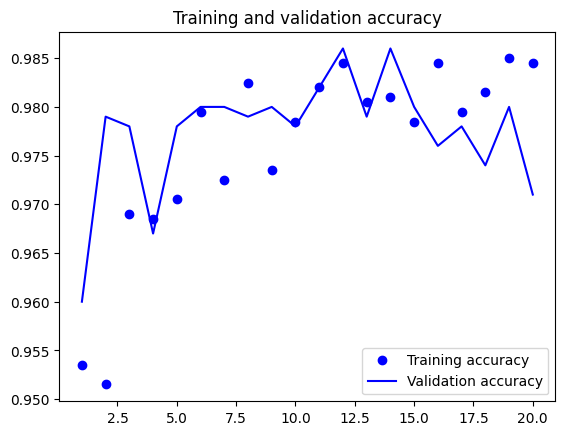

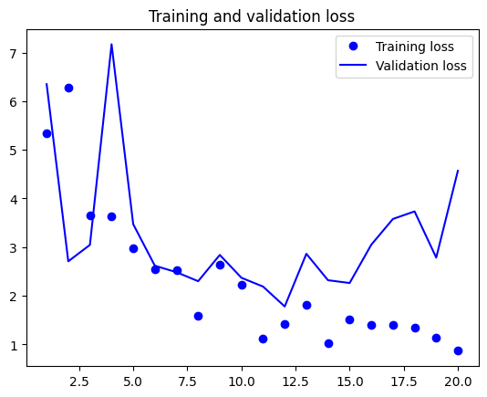

```python
acc = history.history["accuracy"]
val_acc = history.history["val_accuracy"]
loss = history.history["loss"]
val_loss = history.history["val_loss"]
epochs = range(1, len(acc) + 1)
plt.plot(epochs, acc, "bo", label="Training accuracy")
plt.plot(epochs, val_acc, "b", label="Validation accuracy")
plt.title("Training and validation accuracy")
plt.legend()
plt.figure()
plt.plot(epochs, loss, "bo", label="Training loss")
plt.plot(epochs, val_loss, "b", label="Validation loss")
plt.title("Training and validation loss")
plt.legend()
plt.show()
```

**Evaluating the model on the test set**

```python
test_model = keras.models.load_model(
    "./models/feature_extraction_with_data_augmentation.keras")
test_loss, test_acc = test_model.evaluate(test_dataset)
print(f"Test accuracy: {test_acc:.3f}")
```

```
63/63 ━━━━━━━━━━━━━━━━━━━━ 214s 3s/step - accuracy: 0.9795 - loss: 3.1275
Test accuracy: 0.979
```

### 3.2.4 Fine-tuning a pretrained model

```python
conv_base.summary()
```

```
Model: "vgg16"
```

```
┏━━━━━━━━━━━━━━━━━━━━━━━━━━━━━━━━━┳━━━━━━━━━━━━━━━━━━━━━━━━┳━━━━━━━━━━━━━━━┓
┃ Layer (type)                    ┃ Output Shape           ┃       Param # ┃
┡━━━━━━━━━━━━━━━━━━━━━━━━━━━━━━━━━╇━━━━━━━━━━━━━━━━━━━━━━━━╇━━━━━━━━━━━━━━━┩
│ input_layer_7 (InputLayer)      │ (None, None, None, 3)  │             0 │
├─────────────────────────────────┼────────────────────────┼───────────────┤
│ block1_conv1 (Conv2D)           │ (None, None, None, 64) │         1,792 │
├─────────────────────────────────┼────────────────────────┼───────────────┤
│ block1_conv2 (Conv2D)           │ (None, None, None, 64) │        36,928 │
├─────────────────────────────────┼────────────────────────┼───────────────┤
│ block1_pool (MaxPooling2D)      │ (None, None, None, 64) │             0 │
├─────────────────────────────────┼────────────────────────┼───────────────┤
│ block2_conv1 (Conv2D)           │ (None, None, None,     │        73,856 │
│                                 │ 128)                   │               │
├─────────────────────────────────┼────────────────────────┼───────────────┤
│ block2_conv2 (Conv2D)           │ (None, None, None,     │       147,584 │
│                                 │ 128)                   │               │
├─────────────────────────────────┼────────────────────────┼───────────────┤
│ block2_pool (MaxPooling2D)      │ (None, None, None,     │             0 │
│                                 │ 128)                   │               │
├─────────────────────────────────┼────────────────────────┼───────────────┤
│ block3_conv1 (Conv2D)           │ (None, None, None,     │       295,168 │
│                                 │ 256)                   │               │
├─────────────────────────────────┼────────────────────────┼───────────────┤
│ block3_conv2 (Conv2D)           │ (None, None, None,     │       590,080 │
│                                 │ 256)                   │               │
├─────────────────────────────────┼────────────────────────┼───────────────┤
│ block3_conv3 (Conv2D)           │ (None, None, None,     │       590,080 │
│                                 │ 256)                   │               │
├─────────────────────────────────┼────────────────────────┼───────────────┤
│ block3_pool (MaxPooling2D)      │ (None, None, None,     │             0 │
│                                 │ 256)                   │               │
├─────────────────────────────────┼────────────────────────┼───────────────┤
│ block4_conv1 (Conv2D)           │ (None, None, None,     │     1,180,160 │
│                                 │ 512)                   │               │
├─────────────────────────────────┼────────────────────────┼───────────────┤
│ block4_conv2 (Conv2D)           │ (None, None, None,     │     2,359,808 │
│                                 │ 512)                   │               │
├─────────────────────────────────┼────────────────────────┼───────────────┤
│ block4_conv3 (Conv2D)           │ (None, None, None,     │     2,359,808 │
│                                 │ 512)                   │               │
├─────────────────────────────────┼────────────────────────┼───────────────┤
│ block4_pool (MaxPooling2D)      │ (None, None, None,     │             0 │
│                                 │ 512)                   │               │
├─────────────────────────────────┼────────────────────────┼───────────────┤
│ block5_conv1 (Conv2D)           │ (None, None, None,     │     2,359,808 │
│                                 │ 512)                   │               │
├─────────────────────────────────┼────────────────────────┼───────────────┤
│ block5_conv2 (Conv2D)           │ (None, None, None,     │     2,359,808 │
│                                 │ 512)                   │               │
├─────────────────────────────────┼────────────────────────┼───────────────┤
│ block5_conv3 (Conv2D)           │ (None, None, None,     │     2,359,808 │
│                                 │ 512)                   │               │
├─────────────────────────────────┼────────────────────────┼───────────────┤
│ block5_pool (MaxPooling2D)      │ (None, None, None,     │             0 │
│                                 │ 512)                   │               │
└─────────────────────────────────┴────────────────────────┴───────────────┘
```

```
 Total params: 14,714,688 (56.13 MB)
```

```
 Trainable params: 0 (0.00 B)
```

```
 Non-trainable params: 14,714,688 (56.13 MB)
```

```python
conv_base.trainable = True
for layer in conv_base.layers[:-6]:
    layer.trainable = False
```

```python
model.summary()
```

```
Model: "functional_14"
```

```
┏━━━━━━━━━━━━━━━━━━━━━┳━━━━━━━━━━━━━━━━━━━┳━━━━━━━━━━━━┳━━━━━━━━━━━━━━━━━━━┓
┃ Layer (type)        ┃ Output Shape      ┃    Param # ┃ Connected to      ┃
┡━━━━━━━━━━━━━━━━━━━━━╇━━━━━━━━━━━━━━━━━━━╇━━━━━━━━━━━━╇━━━━━━━━━━━━━━━━━━━┩
│ input_layer_8       │ (None, 180, 180,  │          0 │ -                 │
│ (InputLayer)        │ 3)                │            │                   │
├─────────────────────┼───────────────────┼────────────┼───────────────────┤
│ sequential_1        │ (None, 180, 180,  │          0 │ input_layer_8[0]… │
│ (Sequential)        │ 3)                │            │                   │
├─────────────────────┼───────────────────┼────────────┼───────────────────┤
│ get_item_3          │ (None, 180, 180)  │          0 │ sequential_1[0][… │
│ (GetItem)           │                   │            │                   │
├─────────────────────┼───────────────────┼────────────┼───────────────────┤
│ get_item_4          │ (None, 180, 180)  │          0 │ sequential_1[0][… │
│ (GetItem)           │                   │            │                   │
├─────────────────────┼───────────────────┼────────────┼───────────────────┤
│ get_item_5          │ (None, 180, 180)  │          0 │ sequential_1[0][… │
│ (GetItem)           │                   │            │                   │
├─────────────────────┼───────────────────┼────────────┼───────────────────┤
│ stack_4 (Stack)     │ (None, 180, 180,  │          0 │ get_item_3[0][0], │
│                     │ 3)                │            │ get_item_4[0][0], │
│                     │                   │            │ get_item_5[0][0]  │
├─────────────────────┼───────────────────┼────────────┼───────────────────┤
│ add_1 (Add)         │ (None, 180, 180,  │          0 │ stack_4[0][0]     │
│                     │ 3)                │            │                   │
├─────────────────────┼───────────────────┼────────────┼───────────────────┤
│ vgg16 (Functional)  │ (None, 5, 5, 512) │ 14,714,688 │ add_1[0][0]       │
├─────────────────────┼───────────────────┼────────────┼───────────────────┤
│ flatten_3 (Flatten) │ (None, 12800)     │          0 │ vgg16[0][0]       │
├─────────────────────┼───────────────────┼────────────┼───────────────────┤
│ dense_5 (Dense)     │ (None, 256)       │  3,277,056 │ flatten_3[0][0]   │
├─────────────────────┼───────────────────┼────────────┼───────────────────┤
│ dropout_3 (Dropout) │ (None, 256)       │          0 │ dense_5[0][0]     │
├─────────────────────┼───────────────────┼────────────┼───────────────────┤
│ dense_6 (Dense)     │ (None, 1)         │        257 │ dropout_3[0][0]   │
└─────────────────────┴───────────────────┴────────────┴───────────────────┘
```

```
 Total params: 21,269,316 (81.14 MB)
```

```
 Trainable params: 12,716,545 (48.51 MB)
```

```
 Non-trainable params: 5,275,456 (20.12 MB)
```

```
 Optimizer params: 3,277,315 (12.50 MB)
```

Running the following cell on a CPU might take 4 hours.

```python
model.compile(loss="binary_crossentropy",
              optimizer=keras.optimizers.RMSprop(learning_rate=1e-5),
              metrics=["accuracy"])

callbacks = [
    keras.callbacks.ModelCheckpoint(
        filepath="./models/fine_tuning.keras",
        save_best_only=True,
        monitor="val_loss")
]
history = model.fit(
    train_dataset,
    epochs=30,
    validation_data=validation_dataset,
    callbacks=callbacks)
```

```
63/63 ━━━━━━━━━━━━━━━━━━━━ 460s 7s/step - accuracy: 0.9911 - loss: 0.4194 - val_accuracy: 0.9740 - val_loss: 2.5988
63/63 ━━━━━━━━━━━━━━━━━━━━ 424s 7s/step - accuracy: 0.9862 - loss: 0.7851 - val_accuracy: 0.9670 - val_loss: 2.9876
63/63 ━━━━━━━━━━━━━━━━━━━━ 418s 7s/step - accuracy: 0.9866 - loss: 0.7451 - val_accuracy: 0.9780 - val_loss: 1.8858
63/63 ━━━━━━━━━━━━━━━━━━━━ 517s 8s/step - accuracy: 0.9957 - loss: 0.1268 - val_accuracy: 0.9800 - val_loss: 1.7201
63/63 ━━━━━━━━━━━━━━━━━━━━ 455s 7s/step - accuracy: 0.9899 - loss: 0.4813 - val_accuracy: 0.9790 - val_loss: 1.6269
63/63 ━━━━━━━━━━━━━━━━━━━━ 425s 7s/step - accuracy: 0.9953 - loss: 0.1344 - val_accuracy: 0.9760 - val_loss: 1.7769
63/63 ━━━━━━━━━━━━━━━━━━━━ 413s 7s/step - accuracy: 0.9950 - loss: 0.1223 - val_accuracy: 0.9790 - val_loss: 1.7979
63/63 ━━━━━━━━━━━━━━━━━━━━ 463s 7s/step - accuracy: 0.9910 - loss: 0.3581 - val_accuracy: 0.9750 - val_loss: 2.0860
63/63 ━━━━━━━━━━━━━━━━━━━━ 480s 8s/step - accuracy: 0.9934 - loss: 0.1533 - val_accuracy: 0.9790 - val_loss: 2.0776
63/63 ━━━━━━━━━━━━━━━━━━━━ 445s 7s/step - accuracy: 0.9885 - loss: 0.3173 - val_accuracy: 0.9830 - val_loss: 1.7338
63/63 ━━━━━━━━━━━━━━━━━━━━ 496s 8s/step - accuracy: 0.9946 - loss: 0.1105 - val_accuracy: 0.9800 - val_loss: 2.1155
63/63 ━━━━━━━━━━━━━━━━━━━━ 451s 7s/step - accuracy: 0.9987 - loss: 0.0569 - val_accuracy: 0.9780 - val_loss: 2.0539
63/63 ━━━━━━━━━━━━━━━━━━━━ 573s 9s/step - accuracy: 0.9914 - loss: 0.2504 - val_accuracy: 0.9760 - val_loss: 2.6210
63/63 ━━━━━━━━━━━━━━━━━━━━ 719s 11s/step - accuracy: 0.9942 - loss: 0.1270 - val_accuracy: 0.9780 - val_loss: 1.7296
63/63 ━━━━━━━━━━━━━━━━━━━━ 660s 11s/step - accuracy: 0.9960 - loss: 0.1226 - val_accuracy: 0.9780 - val_loss: 1.9415
63/63 ━━━━━━━━━━━━━━━━━━━━ 671s 11s/step - accuracy: 0.9942 - loss: 0.1699 - val_accuracy: 0.9780 - val_loss: 1.8789
63/63 ━━━━━━━━━━━━━━━━━━━━ 551s 9s/step - accuracy: 0.9956 - loss: 0.1285 - val_accuracy: 0.9780 - val_loss: 2.3054
63/63 ━━━━━━━━━━━━━━━━━━━━ 665s 11s/step - accuracy: 0.9962 - loss: 0.0644 - val_accuracy: 0.9790 - val_loss: 1.6444
63/63 ━━━━━━━━━━━━━━━━━━━━ 672s 11s/step - accuracy: 0.9929 - loss: 0.2842 - val_accuracy: 0.9800 - val_loss: 2.0810
63/63 ━━━━━━━━━━━━━━━━━━━━ 570s 9s/step - accuracy: 0.9963 - loss: 0.1321 - val_accuracy: 0.9760 - val_loss: 2.0593
63/63 ━━━━━━━━━━━━━━━━━━━━ 470s 7s/step - accuracy: 0.9962 - loss: 0.0513 - val_accuracy: 0.9770 - val_loss: 2.2306
63/63 ━━━━━━━━━━━━━━━━━━━━ 435s 7s/step - accuracy: 0.9984 - loss: 0.0303 - val_accuracy: 0.9790 - val_loss: 1.8669
63/63 ━━━━━━━━━━━━━━━━━━━━ 475s 8s/step - accuracy: 0.9976 - loss: 0.0269 - val_accuracy: 0.9790 - val_loss: 1.6299
63/63 ━━━━━━━━━━━━━━━━━━━━ 556s 9s/step - accuracy: 0.9943 - loss: 0.1124 - val_accuracy: 0.9780 - val_loss: 1.9285
63/63 ━━━━━━━━━━━━━━━━━━━━ 529s 8s/step - accuracy: 0.9978 - loss: 0.0510 - val_accuracy: 0.9820 - val_loss: 2.0392
63/63 ━━━━━━━━━━━━━━━━━━━━ 483s 8s/step - accuracy: 0.9950 - loss: 0.1511 - val_accuracy: 0.9810 - val_loss: 1.6053
63/63 ━━━━━━━━━━━━━━━━━━━━ 431s 7s/step - accuracy: 0.9915 - loss: 0.3211 - val_accuracy: 0.9780 - val_loss: 1.9757
63/63 ━━━━━━━━━━━━━━━━━━━━ 434s 7s/step - accuracy: 0.9975 - loss: 0.0533 - val_accuracy: 0.9790 - val_loss: 1.6408
63/63 ━━━━━━━━━━━━━━━━━━━━ 404s 6s/step - accuracy: 0.9980 - loss: 0.0403 - val_accuracy: 0.9750 - val_loss: 2.2148
63/63 ━━━━━━━━━━━━━━━━━━━━ 390s 6s/step - accuracy: 0.9954 - loss: 0.0824 - val_accuracy: 0.9820 - val_loss: 1.3983
```

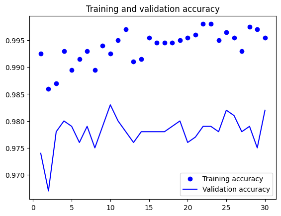

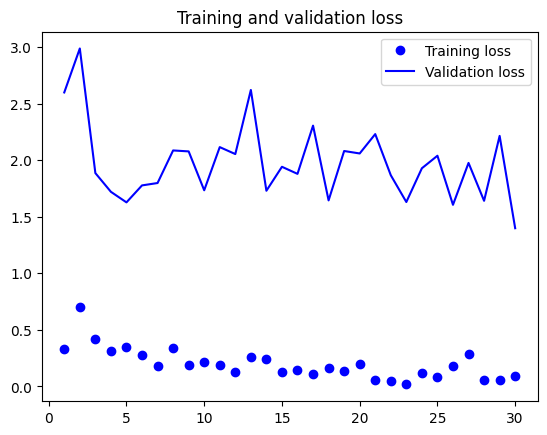

```python
acc = history.history["accuracy"]
val_acc = history.history["val_accuracy"]
loss = history.history["loss"]
val_loss = history.history["val_loss"]
epochs = range(1, len(acc) + 1)
plt.plot(epochs, acc, "bo", label="Training accuracy")
plt.plot(epochs, val_acc, "b", label="Validation accuracy")
plt.title("Training and validation accuracy")
plt.legend()
plt.figure()
plt.plot(epochs, loss, "bo", label="Training loss")
plt.plot(epochs, val_loss, "b", label="Validation loss")
plt.title("Training and validation loss")
plt.legend()
plt.show()
```

```python
model = keras.models.load_model("./models/fine_tuning.keras")
test_loss, test_acc = model.evaluate(test_dataset)
print(f"Test accuracy: {test_acc:.3f}")
```

```
63/63 ━━━━━━━━━━━━━━━━━━━━ 228s 4s/step - accuracy: 0.9762 - loss: 1.9899
Test accuracy: 0.978
```